# Practical Machine Learning: Human Activity Recognition

Sebastian Castro

20 December 2014

## Introduction

The availability of small devices built with sensors like accelerometers has created a whole movement of enthusiasts that use the data to understand and learn about human activity. Also it has opened up a new line of research, with the collection of large quantities of data and the use of machine learning algorithms to map raw data to activity.

This reports benefits from the work done by a research group from Departamento de Informática at the Pontifical Catholic University of Rio de Janeiro, that designed and executed an experiment were subjects wore sensors while executing a set of controlled weight lifting exercises, some of them well executed and the rest including some typical mistakes. With the data and a set of machine learning algorithms, they recognized the mistakes based on the collected data.

For more information, check the details at their [site](http://groupware.les.inf.puc-rio.br/har)

## Objective

This work aims to use the weight lifting dataset prepared by the Brazilian team to train a model and produce prediction for 20 experiment. Each experiment contains several variables collected during the execution, and a value from ‘A’ to ‘E’ identifying the type of experiment. Our model will need to learn from the variables and produce a correct classification.

## Data exploration and cleanup

First, the data is loaded and some exploration is attempted. Because there are 160 variables for each experiment, using *pairs* to plot won’t create something meaningful.

```r
set.seed(50127)
if (!file.exists("pml-training.csv")) {
  download.file("https://d396qusza40orc.cloudfront.net/predmachlearn/pml-training.csv", "pml-training.csv", method="curl")
}
raw_train_data <- read.csv("pml-training.csv", header=TRUE)
nrow(raw_train_data)
```

```
## [1] 19622
```

```r
ncol(raw_train_data)
```

```
## [1] 160
```

```r
message("Summary of some of the variables")
```

```
## Summary of some of the variables
```

```r
summary(raw_train_data[, c("X", "user_name", "min_yaw_forearm", "amplitude_roll_forearm", "roll_belt", "pitch_belt")])
```

```
##        X            user_name    min_yaw_forearm amplitude_roll_forearm
##  Min.   :    1   adelmo  :3892          :19216   Min.   :  0
##  1st Qu.: 4906   carlitos:3112   #DIV/0!:   84   1st Qu.:  1
##  Median : 9812   charles :3536   -1.2   :   32   Median : 18
##  Mean   : 9812   eurico  :3070   -1.3   :   31   Mean   : 25
##  3rd Qu.:14717   jeremy  :3402   -1.4   :   24   3rd Qu.: 40
##  Max.   :19622   pedro   :2610   -1.5   :   24   Max.   :126
##                                  (Other):  211   NA's   :19216
##    roll_belt       pitch_belt
##  Min.   :-28.9   Min.   :-55.80
##  1st Qu.:  1.1   1st Qu.:  1.76
##  Median :113.0   Median :  5.28
##  Mean   : 64.4   Mean   :  0.31
##  3rd Qu.:123.0   3rd Qu.: 14.90
##  Max.   :162.0   Max.   : 60.30
##
```

Upon visual exploration using *summary* (not included due to length), the original training data contains three major groups of columns: those that are useless to the model, like *X* and *user_name*, those with majority of NULL or NAs values, like *min_yaw_forearm* and *amplitude_roll_forearm* and the rest, which are preserved for the model.

```r
 clean_train_data <- raw_train_data[ , c("roll_belt", "pitch_belt", "yaw_belt", "total_accel_belt", "gyros_belt_x", "gyros_belt_y", "gyros_belt_z", "accel_belt_x", "accel_belt_y", "accel_belt_z", "magnet_belt_x", "magnet_belt_y", "magnet_belt_z", "roll_arm", "pitch_arm", "yaw_arm", "total_accel_arm", "gyros_arm_x", "gyros_arm_y", "gyros_arm_z", "accel_arm_x", "accel_arm_y", "accel_arm_z", "magnet_arm_x", "magnet_arm_y", "magnet_arm_z", "roll_dumbbell", "pitch_dumbbell", "yaw_dumbbell", "total_accel_dumbbell", "gyros_dumbbell_x", "gyros_dumbbell_y", "gyros_dumbbell_z", "accel_dumbbell_x", "accel_dumbbell_y", "accel_dumbbell_z", "magnet_dumbbell_x", "magnet_dumbbell_y", "magnet_dumbbell_z", "roll_forearm", "pitch_forearm", "yaw_forearm", "total_accel_forearm", "gyros_forearm_x", "gyros_forearm_y", "gyros_forearm_z", "accel_forearm_x", "accel_forearm_y", "accel_forearm_z", "magnet_forearm_x", "magnet_forearm_y", "magnet_forearm_z", "classe" )]
```

## Model training

We will use Random Forests as training algorithm, therefore a train and a test set is not needed, because the error is estimated internally while the different trees are prepared, and cross validation handled internally as well.

We work with two cross-validation method with Random Forests: Out-of-bag, specific for the algorithm, and Cross-Validation with the default parameters.

```r
library(caret)
library(doMC)
registerDoMC(cores = 4)
Tcontrol1 <- trainControl(method="oob", allowParallel=TRUE )
Tcontrol2 <- trainControl(method="cv", allowParallel=TRUE )
model1 <- train(classe ~ ., data = clean_train_data, method = "rf", trControl=Tcontrol1)
model2 <- train(classe ~ ., data = clean_train_data, method = "rf", trControl=Tcontrol2)
```

Once prepared the models, we check the results

```r
model1
```

```
## Random Forest
##
## 19622 samples
##    52 predictor
##     5 classes: 'A', 'B', 'C', 'D', 'E'
##
## No pre-processing
## Resampling results across tuning parameters:
##
##   mtry  Accuracy  Kappa
##    2    0.9956    0.9945
##   27    0.9958    0.9947
##   52    0.9904    0.9878
##
## Accuracy was used to select the optimal model using  the largest value.
## The final value used for the model was mtry = 27.
```

```r
model2
```

```
## Random Forest
##
## 19622 samples
##    52 predictor
##     5 classes: 'A', 'B', 'C', 'D', 'E'
##
## No pre-processing
## Resampling: Cross-Validated (10 fold)
##
## Summary of sample sizes: 17660, 17660, 17660, 17660, 17659, 17661, ...
##
## Resampling results across tuning parameters:
##
##   mtry  Accuracy  Kappa   Accuracy SD  Kappa SD
##    2    0.9953    0.9940  0.002067     0.002615
##   27    0.9952    0.9939  0.001984     0.002509
##   52    0.9896    0.9868  0.003002     0.003798
##
## Accuracy was used to select the optimal model using  the largest value.
## The final value used for the model was mtry = 2.
```

```r
m1 <- confusionMatrix(clean_train_data$classe, predict(model1, clean_train_data))
m2 <- confusionMatrix(clean_train_data$classe, predict(model2, clean_train_data))
```

Visually we can see the accuracy per class using a Normalized Confusion Matrix.

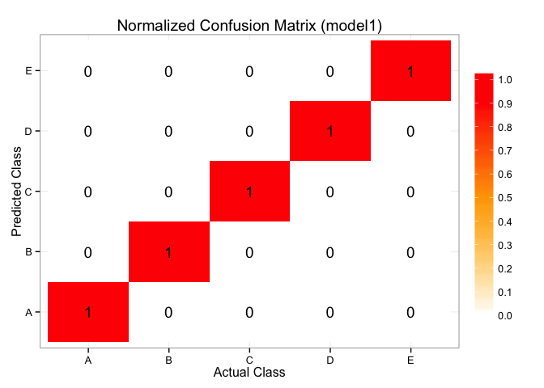

```r
library(ggplot2)
t <- table(clean_train_data$classe, predict(model1, clean_train_data))
norm_conf_matrix <- as.data.frame(t/rowSums(t, 5))
ggplot(norm_conf_matrix, aes(x=Var1, y=Var2, fill=Freq)) + geom_tile() + scale_fill_gradient2("", breaks=seq(from=0, to=1, by=.1), low="white", high="red", mid="orange", midpoint=0.5) + theme_bw() + labs(x="Actual Class", y="Predicted Class", title="Normalized Confusion Matrix (model1)") + geom_text(aes(label=Freq)) + guides(fill=guide_colorbar(barheight=16))
```

And repeat for Model 2.

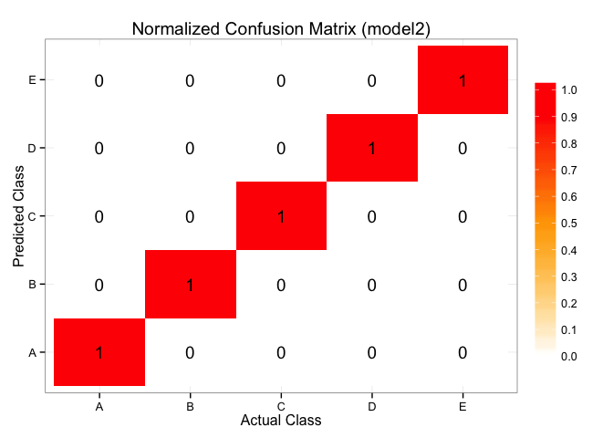

```r
t <- table(clean_train_data$classe, predict(model2, clean_train_data))
norm_conf_matrix <- as.data.frame(t/rowSums(t, 5))
ggplot(norm_conf_matrix, aes(x=Var1, y=Var2, fill=Freq)) + geom_tile() + scale_fill_gradient2("", breaks=seq(from=0, to=1, by=.1), low="white", high="red", mid="orange", midpoint=0.5) + theme_bw() + labs(x="Actual Class", y="Predicted Class", title="Normalized Confusion Matrix (model2)") + geom_text(aes(label=Freq)) + guides(fill=guide_colorbar(barheight=16))
```

## Prediction

Finally we take the test data, and generate the corresponding predictions using both models.

```r
if (!file.exists("pml-testing.csv")) {
  download.file("https://d396qusza40orc.cloudfront.net/predmachlearn/pml-testing.csv", "pml-testing.csv", method="curl")
}
test_data <- read.csv("pml-testing.csv", header=TRUE)
predict(model1, test_data)
```

```
##  [1] B A B A A E D B A A B C B A E E A B B B
## Levels: A B C D E
```

```r
predict(model2, test_data)
```

```
##  [1] B A B A A E D B A A B C B A E E A B B B
## Levels: A B C D E
```

```r
answers = rep("A", 20)
pml_write_files = function(x){
  n = length(x)
  for(i in 1:n){
    filename = paste0("problem_id_",i,".txt")
    write.table(x[i],file=filename,quote=FALSE,row.names=FALSE,col.names=FALSE)
  }
}
answers <- predict(model1, test_data)
```